# One Y Variable

Module 2.3: Distributions

Alex Cardazzi

Old Dominion University

## Distributions

So far, we have characterized certain “moments” of data (i.e., mean and variance).

While these two numbers are helpful, they do not tell the full story. As an example, let’s consider the following data:

```r
df <- read.csv("https://vincentarelbundock.github.io/Rdatasets/csv/datasets/anscombe.csv")
cat("Summary Statistics for x1. Mean:", mean(df$x1), "; Variance:", var(df$x1), "\n")
cat("Summary Statistics for x4. Mean:", mean(df$x4), "; Variance:", var(df$x4))
```

**Output**

```
Summary Statistics for x1. Mean: 9 ; Variance: 11
Summary Statistics for x4. Mean: 9 ; Variance: 11
```

Now, check out the underlying data:

```r
df[,c("x1", "x4")]
```

**Output**

```
   x1 x4
1  10  8
2   8  8
3  13  8
4   9  8
5  11  8
6  14  8
7   6  8
8   4 19
9  12  8
10  7  8
11  5  8
```

## Distributions

Clearly, even those data have the same mean and variance, they have very different *distributions*. This is different than the case of Michael Jordan and UNC. There, the distributions were in fact very similar except for Michael Jordan’s outlier salary.

Before we can keep talking about distributions, we need to discuss probability briefly.

## Probability

**Probability**

A value between 0 and 1 inclusive that represents the likelihood a particular event happens.

The probability that a coin is flipped and it lands on tails is $\frac{1}{2}$ or $0.5$ or $50\%$.<sup>1</sup> What about the probabilities and outcomes of flipping two coins and counting the number of tails? Well, since flipping this coin is a **random variable**, it has a distribution. That distribution is defined by all possible outcomes and the associated probabilities:

Probability Distribution of Two Coin Flips

| Number of Tails, $y$ | Probability, $P(y)$ |
| --- | --- |
| 0 | 0.25 |
| 1 | 0.50 |
| 2 | 0.25 |

[^1]: Percentages are not *really* probabilities, but they are often associated with them.

## Probability

All distributions have a mean and a variance.<sup>1</sup> So, how do we find the mean and variance of a probability distribution?

$$\mu = \sum_{i = 1}^g P(y_i) \times y_i$$

$$\sigma^2 = \sum_{i = 1}^g P(y_i) \times (y_i - \mu)^2$$

**Note**: this should look a lot like the formula for weighted average.

[^2]: Not *really*, but distributions without a mean and/or variance are outside the scope of this course.

## Probability

To practice, let’s use the previous distribution of flipping two coins.

$$\mu = \sum_{i = 1}^g P(y_i) \times y_i = (0.25\times0) + (0.5\times1) + (0.25\times2) = 1$$

$$\begin{aligned}\sigma^2 &= \sum_{i = 1}^g P(y_i) \times (y_i - \mu)^2 \\
&= (0.25\times(0-1)^2) + (0.5\times(1-1)^2) + (0.25\times(2-1)^2) \\
&= (0.25\times(-1)^2) + (0.5\times(0)^2) + (0.25\times(1)^2) \\
&= 0.25 + 0 + 0.25 = 0.5\end{aligned}$$

## Probability

Flipping coins is an example of a *discrete* distribution. In other words, individual events have non-zero probabilities of occurring. However, when distributions are *continuous*, the probability of any specific outcome occurring is precisely zero. What? How can that be true?

Consider the lifespan of a tire on a car. The average tire lasts about 54,000 miles. However, what is the probability that your tire lasts **exactly** 54,000 miles? Essentially 0%.

This is because your tire could last 54,000.1 miles, 54,000.01 miles, and so on. There are an infinite number of miles that your tire could last, so the probability of any specific mile being the one where your tire blows is zero.

## Probability

When dealing with continuous probabilities, instead of asking for the $P(y) = M$ (e.g., the probability that your tire lasts exactly $M$ miles), people ask for the $P(y) < M$, $P(y) > m$, or $m < P(y) < M$ (e.g., the probability that your tire lasts more or less than some number of miles, or the probability that your tire lasts between two numbers of miles.)

In the interest of being concrete, suppose tires last anywhere between 40,000 and 68,000 miles. The distribution is uniform, meaning that the probability of your tire blowing up is the same from 40,000 to 68,000 miles. A question from a statistics class might be: “what is the probability that your tire lasts more than 60,000 miles?”

To answer this, you need to know what fraction of tires last above 60,000. Well, since all tires blow up between 40 and 68, we can say the baseline is 68-40 = 28. Then, 68-60 is the range we’re interested in. So, the probability would be $\frac{8}{28} = 0.286$.

## The Normal Distribution

The above math highlights how you would deal with probabilities and continuous distributions. However, not all continuous distributions are “uniform” like we assumed above. Perhaps the most famous and widely studied distribution is **the normal distribution**.

The normal distribution:

- is bell-shaped with it’s peak in the center
- is symmetric, meaning the mean is the same as the median, and it asymptotically approaches the x-axis (meaning it gets close but never touches it!)
- is completely characterized by its mean and standard deviation, and is written like $N(\mu, \sigma)$

## The Normal Distribution

Below is an example of what a normal distribution looks like:

**Plot**

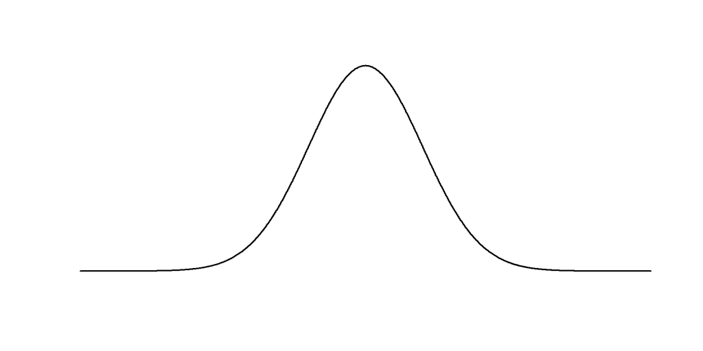

Example of a Normal Distribution

## Multiple Normal Distributions

Normal distributions take on different shapes depending on their means and standard deviations.

- A increasing the mean, while holding the standard deviation constant, results in the distribution sliding horizontally to the right along the x-axis.
- An increase in the standard deviation, while holding the mean constant, results in a shorter, wider distribution.

Below are some examples of what these changes would do to a standard normal distribution:

**Plot**

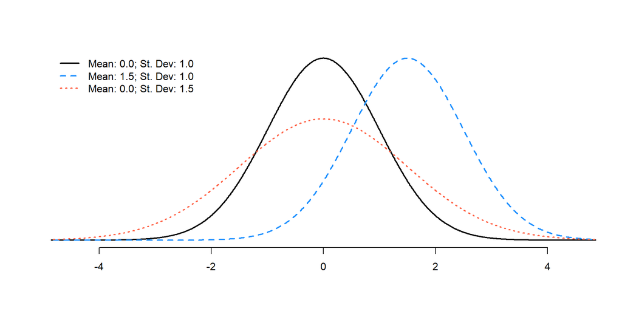

Example of Multiple Normal Distributions

## Normal Distribution Application

To learn the most incredible feature of the normal distribution, you’ll have to wait for later in the module. However, while we wait, let’s discuss how to compare two different normal distributions.

Two particularly famous distributions that are normally distributed are scores on the SAT and ACT. The maximum score for each is 1600 and 36, respectively. The SAT has an average score of 1050 with a standard deviation of 200. The ACT has an average score of 19 with a standard deviation of 6.

So, let’s say someone scores a 1,300 on the SAT and a 29 on the ACT. Which test did they do better on?

## Normal Distribution Application

Well, let’s first visualize the two distributions and the two scores.

**Plot**

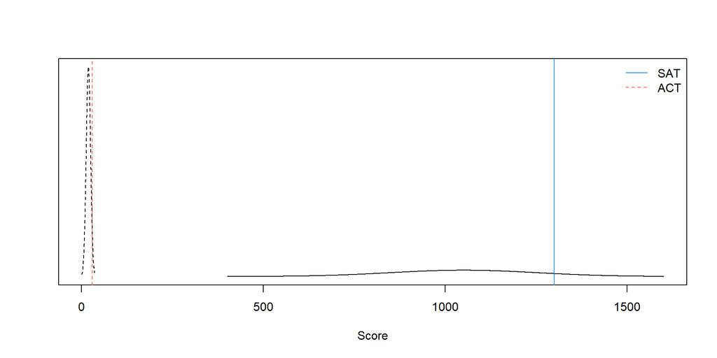

## Normal Distribution Application

Well, this visualization is not helpful. Since the two distributions have different means and standard deviations, we cannot really compare them. A first step to getting a better comparison would be to subtract off the mean from both distributions. Then, both distributions will have a mean of zero.

**Plot**

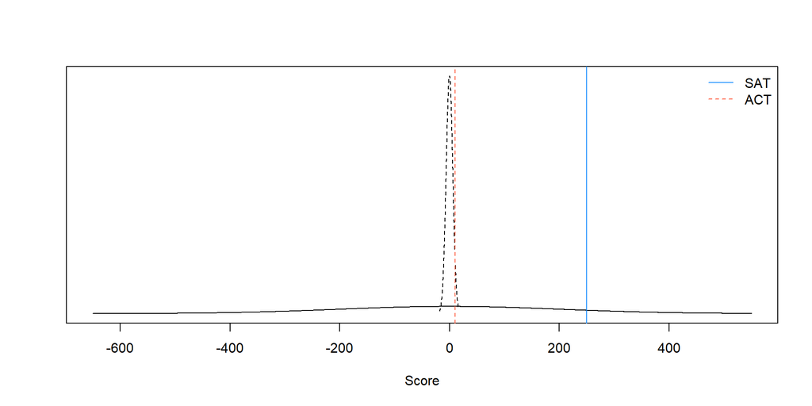

## Normal Distribution Application

**Plot**

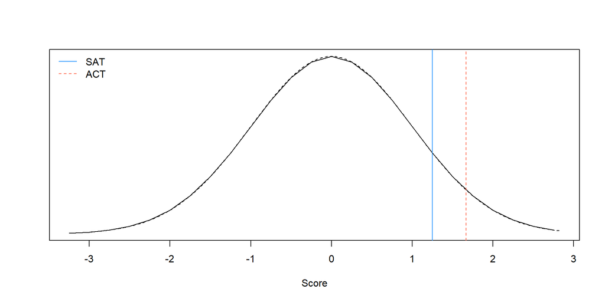

## Normal Distribution Application

Now, it should be quite obvious which score was “better”. The SAT score currently has a value of 1.25 while the ACT score has a value of 1.6666667.

What do these numbers mean? In words, this is **the number of standard deviations away from the mean** the original score is. This actually has a name, and it is a $z$-score. The formula for a $z$-score is:

$$z = \frac{y - \mu}{\sigma}$$

## Normal Distribution Application

$z$-scores come from what is called a **standard normal distribution**, which is just a normal distribution with a mean of 0 and standard deviation (and variance) of 1, or $N(0, 1)$. We know *a lot* about the standard normal distribution. For example, we know the probability that a random draw from a normal distribution is greater than some number, less than some number, or between two numbers. In most statistics courses, this is where you’d be shown [a $z$-score table](https://cdn.numerade.com/ask_images/9015239223ae4e049700ac6d60da49c7.jpg). Rather than spending time on this table, here are some takeaways:

- Since the distribution is symmetric, the probability of a random draw being larger (or smaller) than 0 is $\frac{1}{2}$.
- There is a 15.87% chance that a random draw is larger (smaller) than +1 (-1).
- There is a 2.28% chance that a random draw is larger (smaller) than +2 (-2).
  - This means that there is a 95.44% chance that the random draw is between -2 and +2.

## Normal Distributions in R

R has some pre-built functions to work with normal distributions.

- `pnorm()` gives $P(Z < y)$ when `lower.tail = TRUE`. When `lower.tail = FALSE`, this gives $P(Z > y)$
  - `pnorm(0, lower.tail = TRUE)`: 0.5
  - `pnorm(2, lower.tail = FALSE)`: 0.0227501.
- `qnorm()` is the opposite of `pnorm()` in that it converts probabilities into $z$-scores.
- `rnorm()` generates random draws from a normal distribution with a given mean and standard deviation. The default mean is 0 and the default standard deviation is 1.

## Arbitrary Distributions

What about arbitrary distributions that we observe in data? We know how to calculate the mean and variance of a random variable, but it’s helpful to visualize the distribution.

If your data is sufficiently discrete, I prefer to use `table()`. Of course, “sufficiently discrete” is difficult to define. If your data has many unique values, you may need to transform the data via rounding before using `table()`. Otherwise, you can use `hist()` to generate a histogram (which is effectively what `table()` is doing) or `density()` to create a kernel density plot. You can think of kernel density plots as smoothed out histograms.

## Arbitrary Distributions

Let’s take a look at some [real estate transaction data](https://vincentarelbundock.github.io/Rdatasets/doc/AER/HousePrices.html) as an example.

```r
# https://vincentarelbundock.github.io/Rdatasets/doc/AER/HousePrices.html
df <- read.csv("https://vincentarelbundock.github.io/Rdatasets/csv/AER/HousePrices.csv")
# Keep only columns 2 through 6.
# These rows are the ones that contain numeric data.
# What this step below is doing is sub-setting the columns,
#   then saving over the original.
df <- df[,2:6]
head(df)
```

**Output**

```
  price lotsize bedrooms bathrooms stories
1 42000    5850        3         1       2
2 38500    4000        2         1       1
3 49500    3060        3         1       1
4 60500    6650        3         1       2
5 61000    6360        2         1       1
6 66000    4160        3         1       1
```

## Arbitrary Distributions

First, let’s examine the distribution of bedrooms.

```r
plot(table(df$bedrooms),
     xlab = "Number of Bedrooms",
     ylab = "Frequency")
```

**Plot**

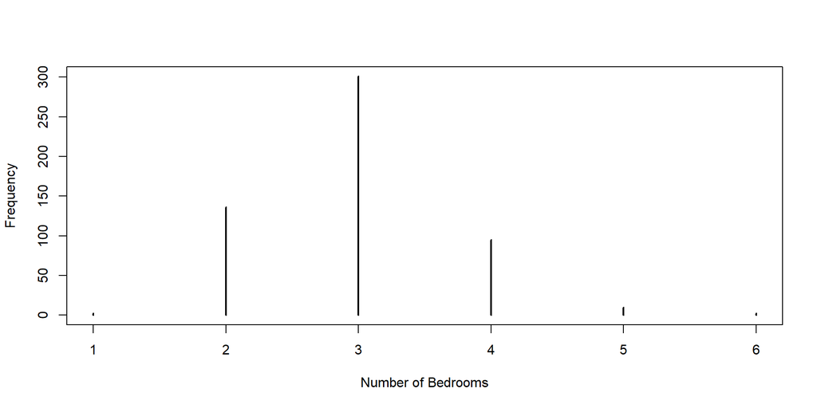

## Arbitrary Distributions

Next, let’s try to plot the distribution of sale price.

```r
plot(table(df$price), xlab = "Sale Price", ylab = "Frequency")
```

**Plot**

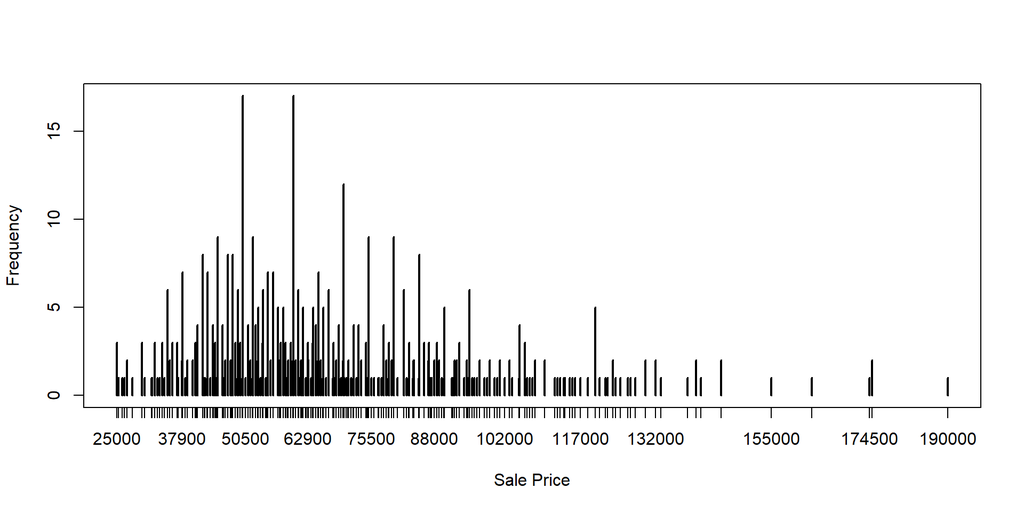

This is not a very informative plot as there’s no discernible pattern. Rather, let’s divide by 10,000, round the data, and re-multiply by 10,000.

```r
plot(table(round(df$price/10000)*10000), xlab = "Sale Price", ylab = "Frequency")
```

**Plot**

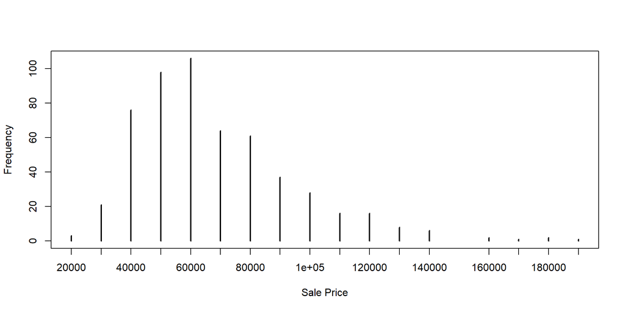

This is a much better plot. We can see that were are some outliers that are over $150,000, and the modal sale is about $60,000.

## Arbitrary Distributions

Finally, we want a way to tabulate multiple summary statistics for multiple variables. To do this, we can use R’s `summary()` function.

```r
summary(df)
```

**Output**

```
     price           lotsize         bedrooms       bathrooms
 Min.   : 25000   Min.   : 1650   Min.   :1.000   Min.   :1.000
 1st Qu.: 49125   1st Qu.: 3600   1st Qu.:2.000   1st Qu.:1.000
 Median : 62000   Median : 4600   Median :3.000   Median :1.000
 Mean   : 68122   Mean   : 5150   Mean   :2.965   Mean   :1.286
 3rd Qu.: 82000   3rd Qu.: 6360   3rd Qu.:3.000   3rd Qu.:2.000
 Max.   :190000   Max.   :16200   Max.   :6.000   Max.   :4.000
    stories
 Min.   :1.000
 1st Qu.:1.000
 Median :2.000
 Mean   :1.808
 3rd Qu.:2.000
 Max.   :4.000
```

## Arbitrary Distributions

However, `summary()` isn’t our best option for creating a table. We are going to use our first *R package* for this task. Using an R package takes two steps. First, you will need to install the package (download the package from the internet onto your computer), and then call the package (loading the package into the current R session). **You only need to install the package once, but you need to call the package every time you use it.**

Below, I am installing the `modelsummary` package and then loading it into our session. You can find [the documentation for `modelsummary` here](https://vincentarelbundock.github.io/modelsummary/index.html).

```r
# only use this once
install.packages("modelsummary")
# use this every time you want to use 'modelsummary'
library("modelsummary")
```

## Arbitrary Distributions

This package contains a few different functions, but we are going to focus on two: `datasummary()` and `datasummary_skim()`. You can find [the documentation for `datasummary` here](https://vincentarelbundock.github.io/modelsummary/articles/datasummary.html). To start, let’s see the output of `datasummary_skim()`.

```r
datasummary_skim(df)
```

|  | Unique (#) | Missing (%) | Mean | SD | Min | Median | Max |  |
| --- | --- | --- | --- | --- | --- | --- | --- | --- |
| price | 219 | 0 | 68121.6 | 26702.7 | 25000.0 | 62000.0 | 190000.0 |  |
| lotsize | 284 | 0 | 5150.3 | 2168.2 | 1650.0 | 4600.0 | 16200.0 |  |
| bedrooms | 6 | 0 | 3.0 | 0.7 | 1.0 | 3.0 | 6.0 |  |
| bathrooms | 4 | 0 | 1.3 | 0.5 | 1.0 | 1.0 | 4.0 |  |
| stories | 4 | 0 | 1.8 | 0.9 | 1.0 | 2.0 | 4.0 |  |

## Arbitrary Distributions

While this provides us with a lot of useful information, it lacks customization. On the other hand, `datasummary()` provides us with much more versatility. To start, take a look at the below example. We are summarizing `price`, `lotsize`, and `bedrooms` from the dataset `df`. For each variable, we are going to calculate `length` (sample size), `Mean`, `SD`, `Min`, and `Max`.

```r
datasummary(price + lotsize + bedrooms ~ length + Mean + SD + Min + Max, data = df)
```

|  | length | Mean | SD | Min | Max |
| --- | --- | --- | --- | --- | --- |
| price | 546.00 | 68121.60 | 26702.67 | 25000.00 | 190000.00 |
| lotsize | 546.00 | 5150.27 | 2168.16 | 1650.00 | 16200.00 |
| bedrooms | 546.00 | 2.97 | 0.74 | 1.00 | 6.00 |

## Arbitrary Distributions

To further complicate this, we can include many other options. However, for simplicity, we are going to focus on the most important ones. First, we are going give the table a title. Second, we are going to rename the variables. Take a look:

```r
title <- "This is the Table's Caption/Title"
frmla <- (`Price` = price) + (`Lot Size` = lotsize) + (`Bedrooms` = bedrooms) ~
  (`N` = length) + Mean + (`St. Dev.` = SD) + Min + Max
datasummary(frmla, data = df, title = title)
```

This is the Table's Caption/Title

|  | N | Mean | St. Dev. | Min | Max |
| --- | --- | --- | --- | --- | --- |
| Price | 546.00 | 68121.60 | 26702.67 | 25000.00 | 190000.00 |
| Lot Size | 546.00 | 5150.27 | 2168.16 | 1650.00 | 16200.00 |
| Bedrooms | 546.00 | 2.97 | 0.74 | 1.00 | 6.00 |

ECON 311: Economics, Causality, and Analytics